# Bad Religion Lyrics Text Analysis

Connor Concannon

July 27, 2018

## Introduction

Bad Religion is a punk band that formed in the Los Angeles area in the early 1980s and continues to make great music and tour today. Since hearing their music almost 20 years ago, I have been an avid follower. Over the course of 30 plus years, and over 20 albums, there are a wealth of lyrics to digest. And this is no ordinary punk band - the group deserves and relishes in the label of [thesaurus punk](https://music.avclub.com/where-to-begin-with-the-thesaurus-punk-of-bad-religion-1798278095). What other band can work in terms like ‘trammel’, ‘entropy’, and ‘fecundity’ at 120 beats per minute? This seemed like a perfect opportunity to put Julia Silge and David Robinson’s book [Tidy Text Mining with R](http://tidytextmining.com) to use.

## Top Words by Sentiment

With a name like Bad Religion, I wasn’t expecting many positive words. Terms like wrong, dead/die, lie, bad, etc. top the list. The words designated as positive are not much better. Usually, when a song includes a word like ‘modern’ it actually isn’t in a positive context - such as ‘modern man, evolutionary destroyer’.

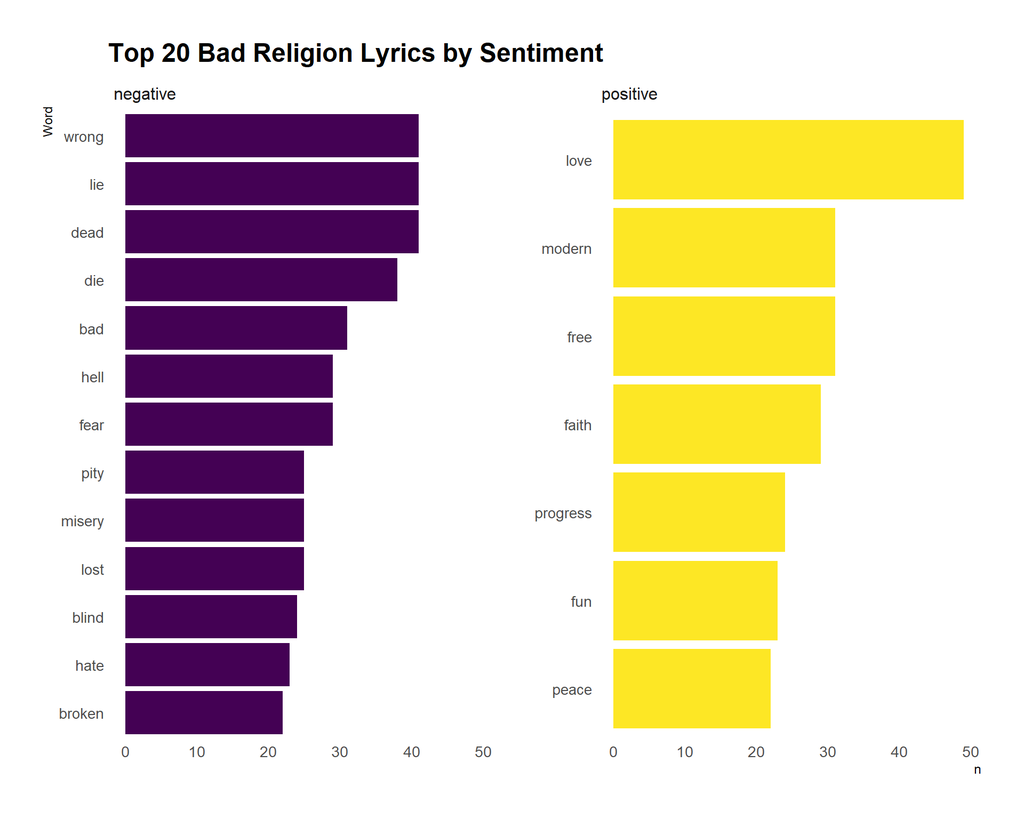

```r
brtidy <- b %>%
  unnest_tokens(word,lyrics) %>%
  anti_join(stop_words)


brsen <- brtidy %>%
  inner_join(get_sentiments("bing"))


brsen %>%
  count(word,sentiment,sort=T) %>%
  top_n(n=20) %>%
  ungroup() %>%
  mutate(Word=reorder(word,n)) %>%
  ggplot(aes(Word,n,fill=sentiment))+
  geom_col()+
  facet_wrap(~sentiment,scales='free_y')+
  coord_flip()+
  theme_ipsum_tw(grid='none')+
  theme(legend.position='none')+
  scale_fill_viridis(discrete=T)+
  labs(title='Top 20 Bad Religion Lyrics by Sentiment')
```

## TF-IDF

[Term frequency inverse document frequency](https://www.tidytextmining.com/tfidf.html#the-bind_tf_idf-function) (TF-IDF) is a technique used to find important words in a particular document - or song in this case. The results of the tf-idf calculation grouped by album are also not surprising. Most of the top words are used in the chorus of songs on that album - and thus repeated many times.

```r
brwords <- brtidy %>%
  count(word,album,sort=T)
total_words <- brwords %>%
  group_by(album) %>%
  summarise(total=sum(n))

total_words
```

```
## # A tibble: 24 x 2
##    album                        total
##    <chr>                        <int>
##  1 80-85                          166
##  2 Against The Grain             1370
##  3 Bad Religion                   283
##  4 Generator                      718
##  5 How Could Hell Be Any Worse?   952
##  6 Into The Unknown               418
##  7 New Maps of Hell              1371
##  8 No Control                     987
##  9 No Substance                  1108
## 10 Punk-O-Rama 8                  186
## # ... with 14 more rows
```

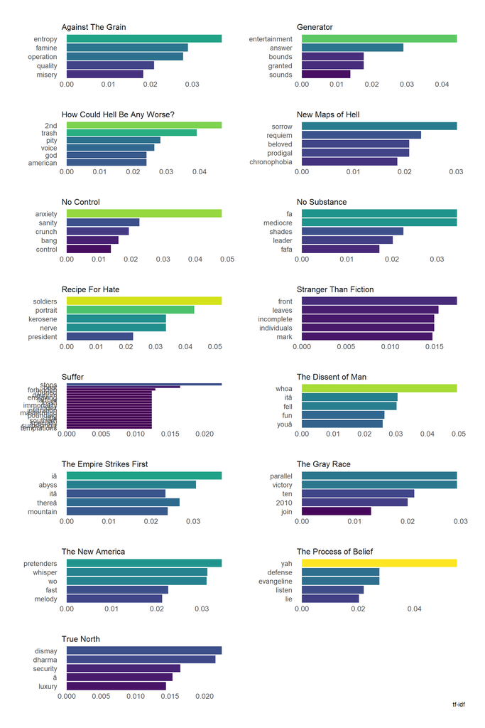

```r
brwords <- left_join(brwords,total_words) %>%
  bind_tf_idf(word,album,n)

#brwords %>% arrange(-tf_idf) %>% View()

brwords %>%
  arrange(desc(tf_idf)) %>%
  mutate(word = factor(word, levels = rev(unique(word)))) %>%
  group_by(album) %>%
  dplyr::filter(total>500) %>%
  top_n(5) %>%
  ungroup %>%
  ggplot(aes(word, tf_idf, fill = tf_idf)) +
  geom_col(show.legend = FALSE) +
  labs(x = NULL, y = "tf-idf") +
  theme_ipsum_tw(grid='none')+
  theme(legend.position='none')+
  scale_fill_viridis()+
  facet_wrap(~album, ncol = 2, scales = "free") +
  coord_flip()
```

## Wordcloud

It had to be done. I am not surprised by any of the high-frequency words in this plot. Many of Bad Religion’s songs cover heady topics like conquering the world, finding truth, and the meaning of life.

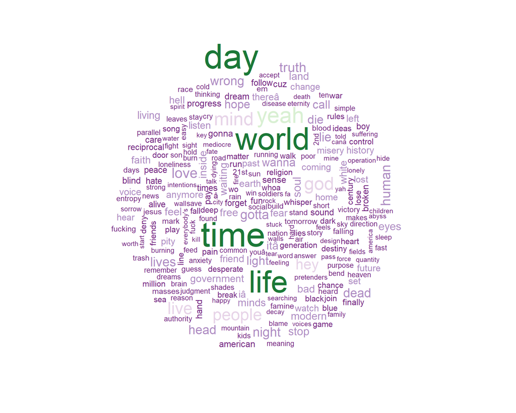

```r
pal <- brewer.pal(6,"PRGn")

brtidy %>%
  count(word) %>%
  with(wordcloud(word,n,max.words=250,colors=pal))
```

## Sentiment Across Albums

This plot is the result of a calculation to derive the aggregate sentiment score (positive words minus negative words) across albums. No album had a positive sentiment score - though I doubt ‘Grandiloquent’ is in the Bing sentiment dictionary! That ‘Stranger than Fiction’ was the album with the lowest sentiment score makes sense - I believe this album was released in the wake of some turmoil between two of the founding members.

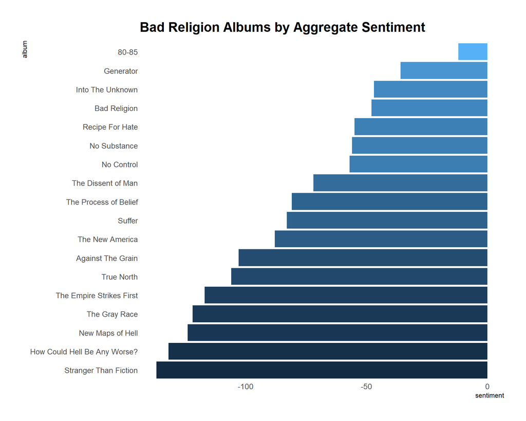

```r
brtidy %>%
  filter(!album %in% c('Short Music For Short People','Punk Rock Song','Tested','Punk-O-Rama 8','Punk Rock Songs (The Epic Years)')) %>%
  inner_join(get_sentiments("bing")) %>%
  count(album,sentiment) %>%
  spread(sentiment,n,fill=0) %>%
  mutate(sentiment=positive-negative) %>%
  mutate(album=reorder(album,sentiment)) %>%
  ggplot(aes(album,sentiment,fill=sentiment))+geom_bar(stat='identity')+
  coord_flip()+
  theme_ipsum_tw(grid='none')+
  theme(legend.position='none')+
  labs(title='Bad Religion Albums by Aggregate Sentiment')
```

## N-Grams

The tables show the highest frequency word pairs across the corpus. Again, many of these bigrams are found in the chorus, and their high frequency makes sense.

```r
bigrams <- b %>%
  unnest_tokens(bigram,lyrics,token='ngrams',n=2)

bigrams %>%
  separate(bigram, c('word1','word2'),sep=" ") %>%
  filter(!word1 %in% stop_words$word) %>%
  filter(!word2 %in% stop_words$word) %>%
  count(word1, word2, sort=T)
```

```
## # A tibble: 3,848 x 3
##    word1    word2          n
##    <chr>    <chr>      <int>
##  1 21st     century       17
##  2 2nd      generation    14
##  3 trash    2nd           14
##  4 white    trash         14
##  5 fast     life          12
##  6 mediocre minds         11
##  7 american dream         10
##  8 bad      religion      10
##  9 yah      yah           10
## 10 american jesus          9
## # ... with 3,838 more rows
```

```r
bigrams %>%
  count(bigram,sort=T)
```

```
## # A tibble: 25,420 x 2
##    bigram        n
##    <chr>     <int>
##  1 in the      222
##  2 and the     135
##  3 of the      120
##  4 on the       92
##  5 to the       82
##  6 i don't      77
##  7 to be        75
##  8 the world    74
##  9 and i        70
## 10 just a       66
## # ... with 25,410 more rows
```

```r
#install.packages('quanteda')

## Topic Modeling
library(methods)
library(quanteda)

#data("data_corpus_inaugural", package = "quanteda")
```